# Efficiency Trial Annual QC

Published

August 4, 2026

```r
library(tidyverse)
library(lubridate)
library(here)
library(glue)
library(DT)

if (file.exists(here::here("DESCRIPTION"))) {
  devtools::load_all(here::here(), quiet = TRUE)
} else {
  library(SRJPEdata)
}

source(here::here("data-raw", "qc", "qc_helpers.R"))

review_run_year <- params$review_run_year
```

## Overview

Reviewing efficiency trial data. Run year being reviewed: **2026**.

Data sources: `weekly_efficiency` (raw trial data), `weekly_juvenile_abundance_efficiency_data` (model-ready), `rst_model_years`.

Efficiency trial records by stream and site

| stream | site | min_run_year | max_run_year | total_trials | total_released |
| --- | --- | --- | --- | --- | --- |
| battle creek | ubc | 2004 | 2025 | 145 | 103384 |
| butte creek | okie dam | 2021 | 2026 | 28 | 5524 |
| clear creek | lcc | 2004 | 2025 | 217 | 124018 |
| clear creek | ucc | 2004 | 2025 | 159 | 78297 |
| deer creek | deer creek | 2023 | 2026 | 20 | 5117 |
| feather river | eye riffle | 1999 | 2026 | 174 | 235868 |
| feather river | gateway riffle | 2013 | 2017 | 50 | 55661 |
| feather river | herringer riffle | 2002 | 2026 | 223 | 295905 |
| feather river | live oak | 1999 | 2001 | 17 | 17064 |
| feather river | steep riffle | 2007 | 2015 | 101 | 112514 |
| feather river | sunset pumps | 2007 | 2011 | 35 | 44522 |
| mill creek | mill creek | 2022 | 2026 | 23 | 6356 |
| sacramento river | knights landing | 1996 | 2025 | 135 | 140791 |
| sacramento river | tisdale | 2012 | 2024 | 54 | 38389 |
| yuba river | hallwood | 2023 | 2025 | 49 | 40202 |

## Check 1 (error): Recaptures Exceeding Releases

Flag trials where `number_recaptured > number_released`. These rows are already filtered out during the model data build, but logging them creates a traceable record for upstream correction.

```r
recap_exceed <- eff |>
  filter(number_recaptured > number_released) |>
  group_by(stream, site, run_year) |>
  summarise(
    n_records    = n(),
    max_ratio    = round(max(number_recaptured / number_released), 2),
    .groups      = "drop"
  )
new_recap_exceed <- log_issues(
  recap_exceed |>
    mutate(
      data_type   = "efficiency",
      issue_type  = "recaptures_exceed_releases",
      field       = "number_recaptured",
      severity    = "critical",
      alert_level = "error",
      description = glue("{n_records} trial(s) in run year {run_year} at {site} ({stream}) have more recaptures than releases. Max recapture/release ratio: {max_ratio}. These rows are filtered at build time.")
    )
)
```

```
  No issues detected for this check.
```

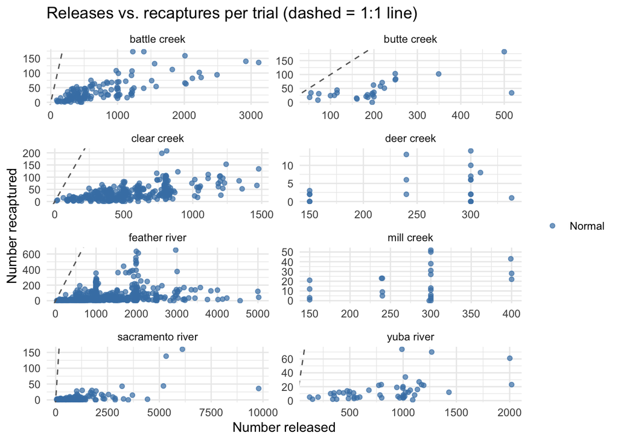

No trials with recaptures exceeding releases.

## Check 2 (warning): Low Release Count

Flag trials where fewer than 50 fish were released. Small releases produce high-variance efficiency estimates.

```r
low_release <- eff |>
  filter(number_released < 50) |>
  group_by(stream, site, run_year) |>
  summarise(
    n_records   = n(),
    min_release = min(number_released),
    .groups     = "drop"
  )

new_low_release <- log_issues(
  low_release |>
    mutate(
      data_type   = "efficiency",
      issue_type  = "low_release_count",
      field       = "number_released",
      severity    = "minor",
      alert_level = "warning",
      description = glue("{n_records} trial(s) with <50 fish released in run year {run_year} at {site} ({stream}). Minimum release count: {min_release}")
    )
)
```

```
  All 6 issue(s) already in log.
```

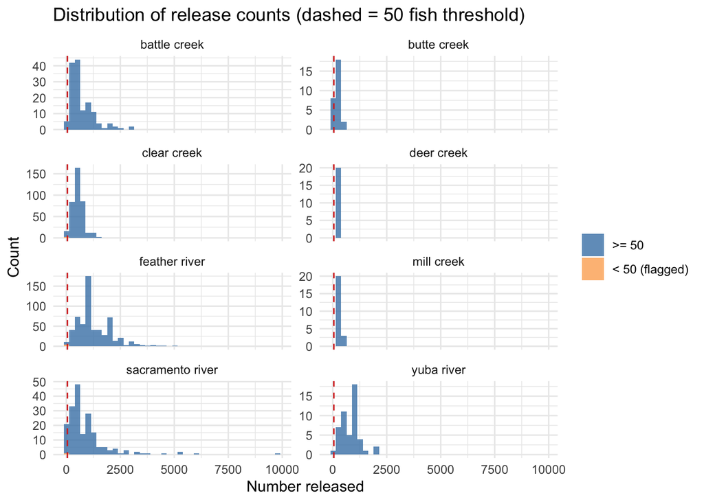

7 trial(s) with <50 releases flagged.

## Check 3 (warning): Zero Recaptures

Flag trials with zero recaptures. Can be real (very low efficiency) but may also indicate a data entry issue.

```r
zero_recap <- eff |>
  filter(number_recaptured == 0) |>
  group_by(stream, site, run_year) |>
  summarise(
    n_records = n(),
    .groups   = "drop"
  )

new_zero_recap <- log_issues(
  zero_recap |>
    mutate(
      data_type   = "efficiency",
      issue_type  = "zero_recaptures",
      field       = "number_recaptured",
      severity    = "minor",
      alert_level = "warning",
      description = glue("{n_records} trial(s) with 0 recaptures in run year {run_year} at {site} ({stream})")
    )
)
```

```
  All 58 issue(s) already in log.
```

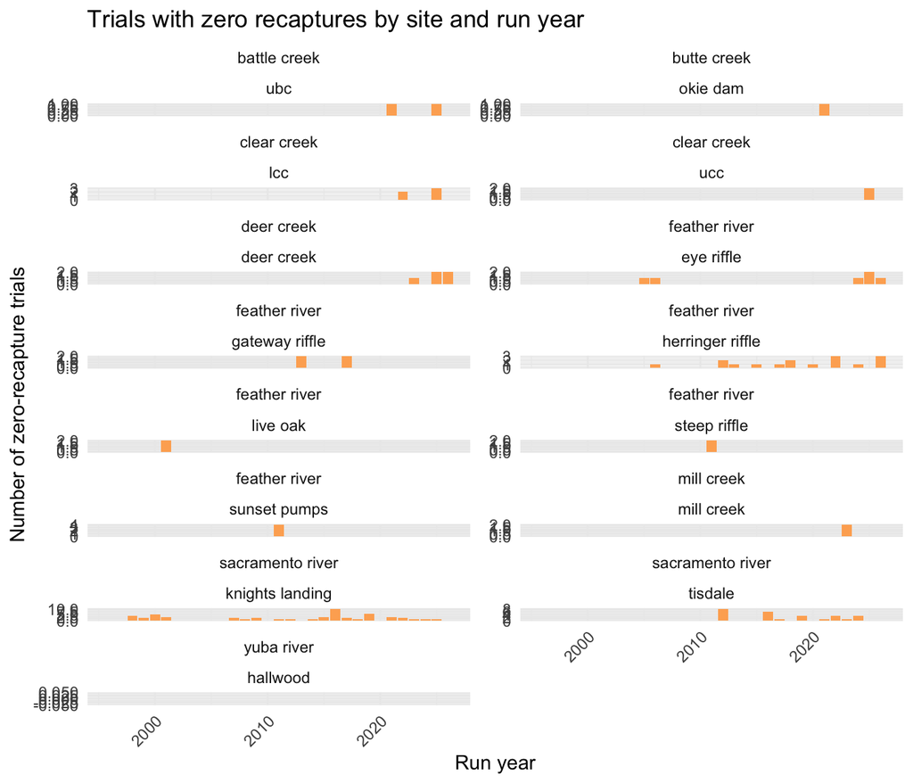

129 zero-recapture trial(s) flagged.

## Check 4 (warning): Trial Coverage Per Run Year

Flag stream/site/run_years with fewer than 3 efficiency trials in the BTSPAS window (weeks 45–53 and 1–22). Indicates sparse coverage that may limit model reliability.

```r
trial_coverage <- weekly_juvenile_abundance_efficiency_data |>
  filter(week %in% c(45:53, 1:22)) |>
  group_by(stream, site, run_year) |>
  summarise(n_trials = n(), .groups = "drop")

excluded_lookup <- rst_model_years |>
  filter(exclude == TRUE) |>
  distinct(stream, site, run_year) |>
  mutate(already_excluded = TRUE)

low_coverage <- trial_coverage |>
  filter(n_trials < 3) |>
  left_join(excluded_lookup, by = c("stream", "site", "run_year")) |>
  mutate(already_excluded = replace_na(already_excluded, FALSE))

new_low_coverage <- log_issues(
  low_coverage |>
    mutate(
      n_records   = n_trials,
      data_type   = "efficiency",
      issue_type  = "low_trial_coverage",
      field       = "n_trials",
      severity    = "moderate",
      alert_level = "warning",
      description = glue("Only {n_trials} efficiency trial(s) in BTSPAS window for run year {run_year} at {site} ({stream}). Already excluded from modeling: {already_excluded}")
    )
)
```

```
  All 19 issue(s) already in log.
```

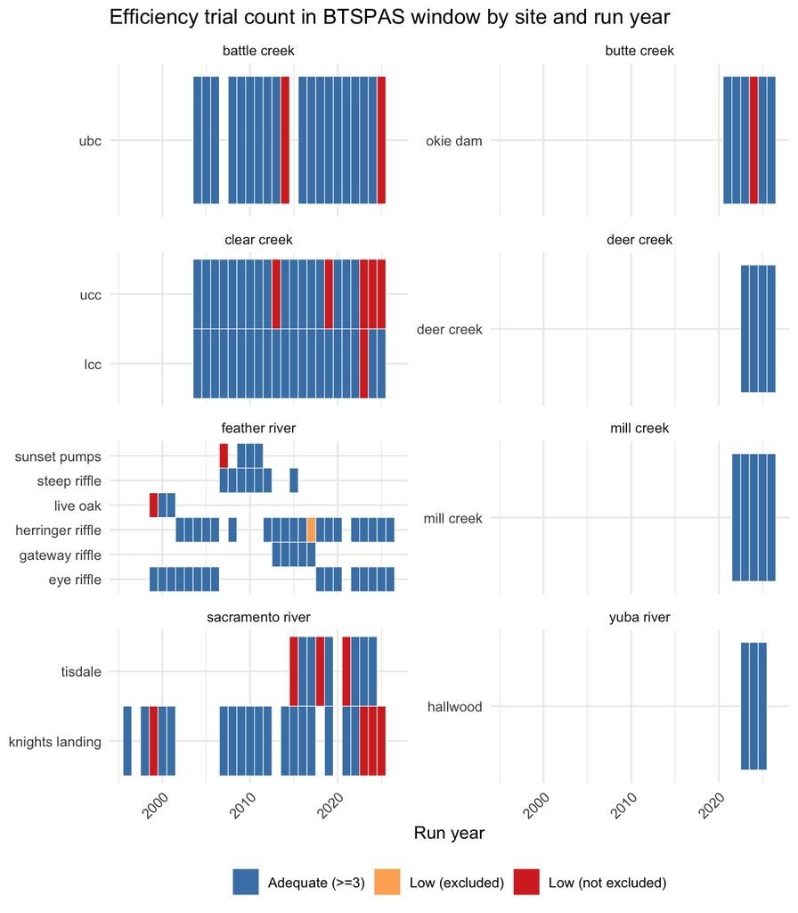

19 site/run-year combination(s) flagged (1 already excluded from modeling).

## Check 5 (error): Efficiency Rate Outliers

For each site with at least 5 years of history, flag run_years where the mean simple efficiency (`number_recaptured / number_released`) is more than 3 SD above the site historical mean.

```r
eff_rates <- eff |>
  filter(number_released > 0, number_recaptured <= number_released) |>
  mutate(simple_eff = number_recaptured / number_released) |>
  group_by(stream, site, run_year) |>
  summarise(mean_eff = mean(simple_eff, na.rm = TRUE), .groups = "drop")

site_eff_stats <- eff_rates |>
  group_by(stream, site) |>
  summarise(
    n_years  = n(),
    hist_mean = mean(mean_eff, na.rm = TRUE),
    hist_sd   = sd(mean_eff, na.rm = TRUE),
    .groups   = "drop"
  ) |>
  filter(n_years >= 5)

eff_rates_eval <- eff_rates |> inner_join(site_eff_stats, by = c("stream", "site"))

eff_outliers <- eff_rates_eval |>
  filter(mean_eff > hist_mean + 3 * hist_sd)

new_eff_outliers <- log_issues(
  eff_outliers |>
    mutate(
      n_records   = 1L,
      data_type   = "efficiency",
      issue_type  = "extreme_value",
      field       = "number_recaptured",
      severity    = "minor",
      alert_level = "error",
      description = glue("Mean efficiency of {round(mean_eff, 3)} in run year {run_year} at {site} ({stream}) is >3 SD above site historical mean ({round(hist_mean, 3)}, SD = {round(hist_sd, 3)})")
    )
)
```

```
  No issues detected for this check.
```

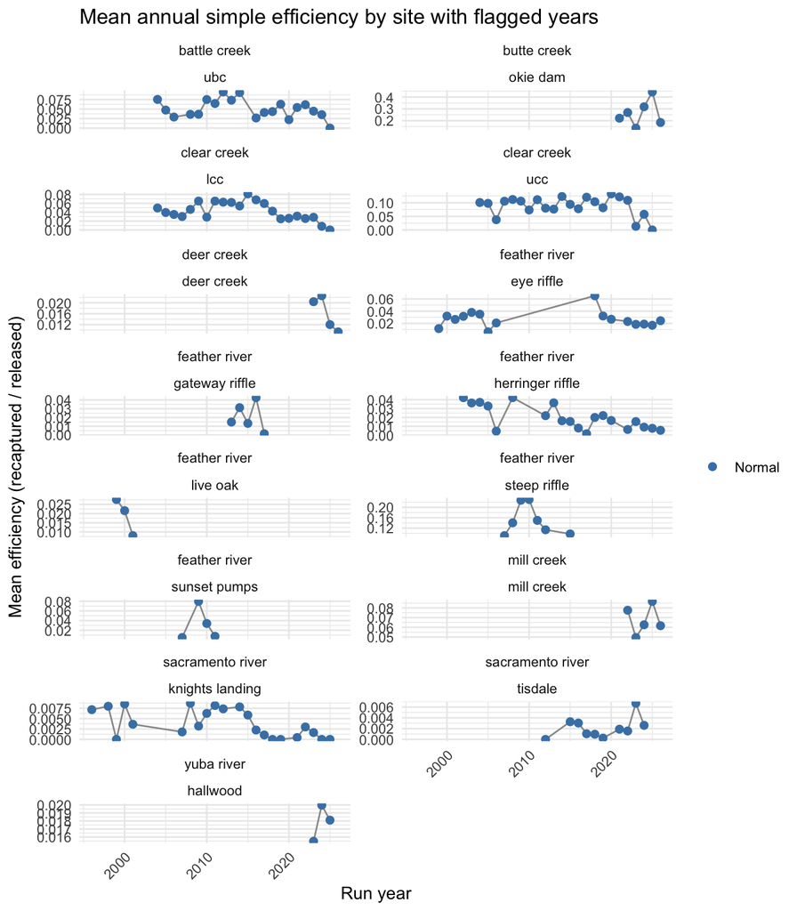

No efficiency rate outliers detected.

## Check 6 (error): No efficiency trials in the given year

```r
active_sites_this_year <- rst_catch |>
  filter(!is.na(date), !is.na(count)) |>
  mutate(run_year = as_run_year(date)) |>
  filter(run_year == review_run_year) |>
  distinct(stream, site)

trials_this_year <- eff |>
  filter(run_year == review_run_year) |>
  distinct(stream, site) |>
  mutate(has_trials = TRUE)

no_trials_eval <- active_sites_this_year |>
  left_join(trials_this_year, by = c("stream", "site")) |>
  mutate(has_trials = replace_na(has_trials, FALSE))

no_trials <- no_trials_eval |> filter(!has_trials)

new_no_trials <- log_issues(
  no_trials |>
    mutate(
      run_year    = review_run_year,
      n_records   = 0L,
      data_type   = "efficiency",
      issue_type  = "no_efficiency_trials",
      field       = "number_released",
      severity    = "critical",
      alert_level = "error",
      description = glue("{site} ({stream}) had RST catch activity in run year {review_run_year} but zero efficiency trials logged anywhere in weekly_efficiency for that year")
    )
)
```

```
  All 5 issue(s) already in log.
```

5 site(s) with catch but zero efficiency trials in run year 2026.

## Issues Logged This Run

```
No new issues logged this run.
```

### All Open Efficiency Issues

| log_id | date_identified | stream | site | run_year | issue_type | field | severity | alert_level | description | reviewer_notes |
| --- | --- | --- | --- | --- | --- | --- | --- | --- | --- | --- |
| efficiency__yuba_river__hallwood__2026__no_efficiency_trials__number_released | 2026-07-29 | yuba river | hallwood | 2026 | no_efficiency_trials | number_released | critical | error | hallwood (yuba river) had RST catch activity in run year 2026 but zero efficiency trials logged anywhere in weekly_efficiency for that year |  |
| efficiency__battle_creek__ubc__2026__no_efficiency_trials__number_released | 2026-07-29 | battle creek | ubc | 2026 | no_efficiency_trials | number_released | critical | error | ubc (battle creek) had RST catch activity in run year 2026 but zero efficiency trials logged anywhere in weekly_efficiency for that year |  |
| efficiency__clear_creek__ucc__2026__no_efficiency_trials__number_released | 2026-07-29 | clear creek | ucc | 2026 | no_efficiency_trials | number_released | critical | error | ucc (clear creek) had RST catch activity in run year 2026 but zero efficiency trials logged anywhere in weekly_efficiency for that year |  |
| efficiency__clear_creek__lcc__2026__no_efficiency_trials__number_released | 2026-07-29 | clear creek | lcc | 2026 | no_efficiency_trials | number_released | critical | error | lcc (clear creek) had RST catch activity in run year 2026 but zero efficiency trials logged anywhere in weekly_efficiency for that year |  |
| efficiency__sacramento_river__knights_landing__2026__no_efficiency_trials__number_released | 2026-07-29 | sacramento river | knights landing | 2026 | no_efficiency_trials | number_released | critical | error | knights landing (sacramento river) had RST catch activity in run year 2026 but zero efficiency trials logged anywhere in weekly_efficiency for that year |  |
| efficiency__clear_creek__lcc__2004__low_release_count__number_released | 2026-07-29 | clear creek | lcc | 2004 | low_release_count | number_released | minor | warning | 1 trial(s) with &lt;50 fish released in run year 2004 at lcc (clear creek). Minimum release count: 14 |  |
| efficiency__clear_creek__ucc__2004__low_release_count__number_released | 2026-07-29 | clear creek | ucc | 2004 | low_release_count | number_released | minor | warning | 1 trial(s) with &lt;50 fish released in run year 2004 at ucc (clear creek). Minimum release count: 20 |  |
| efficiency__feather_river__gateway_riffle__2013__low_release_count__number_released | 2026-07-29 | feather river | gateway riffle | 2013 | low_release_count | number_released | minor | warning | 2 trial(s) with &lt;50 fish released in run year 2013 at gateway riffle (feather river). Minimum release count: 42 |  |
| efficiency__feather_river__herringer_riffle__2018__low_release_count__number_released | 2026-07-29 | feather river | herringer riffle | 2018 | low_release_count | number_released | minor | warning | 1 trial(s) with &lt;50 fish released in run year 2018 at herringer riffle (feather river). Minimum release count: 28 |  |
| efficiency__feather_river__herringer_riffle__2020__low_release_count__number_released | 2026-07-29 | feather river | herringer riffle | 2020 | low_release_count | number_released | minor | warning | 1 trial(s) with &lt;50 fish released in run year 2020 at herringer riffle (feather river). Minimum release count: 40 |  |

[output cut: 78 more lines]